# AI_CA4

University of Tehran  
CA4

Mahdi Noori  
810100231

## Goal

In this notebook we learn about different machine learning models and how to train them and try to anticipate the number of purchases of a store.

## Problem Description

In this problem we will learn about basics of machine learning and different models in order to anticipate the amount of purchases of a store. At first we try to do that by using linear regression without any library, then with gradient descent and at last using Scikit-Learn to do that.

## Imports

```python
import pandas as pd
import numpy as np
import matplotlib.pyplot as plt
import seaborn as sns
import math
from helper import missing_values_count_and_percentage,plot_corr_scatter_hexbin,plot_simple_reg_line,plot_confusion_matrix
from sklearn.preprocessing import StandardScaler, MinMaxScaler
import category_encoders
from sklearn.model_selection import train_test_split
from sklearn.linear_model import LogisticRegression
from sklearn.neighbors import KNeighborsClassifier
from sklearn.tree import DecisionTreeClassifier,plot_tree
from sklearn.model_selection import GridSearchCV
from sklearn.ensemble import RandomForestClassifier
from mlxtend.evaluate import bias_variance_decomp
from xgboost import XGBClassifier
```

## Constants

```python
DATASET_PATH = "./dataset/marketing_campaign.csv"
CORRELATION_THRESHOLD = 0.4
```

## Dataset

Here we use the `marketing_campaign.csv` file as our data set which contains data about the customers of a store and their amount of purchases they have done in last two years.

```python
df = pd.read_csv(DATASET_PATH)
df.head(10)
```

|  | Unnamed: 0 | ID | Year_Birth | Education | Marital_Status | Income | Kidhome | Teenhome | Dt_Customer | Recency | MntCoffee | MntFruits | MntMeatProducts | MntFishProducts | MntSweetProducts | MntGoldProds | NumWebVisitsMonth | Complain | NumPurchases | UsedCampaignOffer |
| --- | --- | --- | --- | --- | --- | --- | --- | --- | --- | --- | --- | --- | --- | --- | --- | --- | --- | --- | --- | --- |
| 0 | 0 | 5524 | 1957 | Graduation | Single | 58138.0 | 0 | 0 | 04-09-2012 | 58 | 635.0 | 88 | 546 | 172 | 88 | 88.0 | NaN | 0 | 25 | 1 |
| 1 | 1 | 2174 | 1954 | Graduation | Single | 46344.0 | 1 | 1 | 08-03-2014 | 38 | NaN | 1 | 6 | 2 | 1 | 6.0 | 5.0 | 0 | 6 | 0 |
| 2 | 2 | 4141 | 1965 | Graduation | Together | 71613.0 | 0 | 0 | 21-08-2013 | 26 | NaN | 49 | 127 | 111 | 21 | 42.0 | NaN | 0 | 21 | 0 |
| 3 | 3 | 6182 | 1984 | Graduation | Together | 26646.0 | 1 | 0 | 10-02-2014 | 26 | 11.0 | 4 | 20 | 10 | 3 | 5.0 | 6.0 | 0 | 8 | 0 |
| 4 | 4 | 5324 | 1981 | PhD | Married | 58293.0 | 1 | 0 | 19-01-2014 | 94 | 173.0 | 43 | 118 | 46 | 27 | 15.0 | 5.0 | 0 | 19 | 0 |
| 5 | 5 | 7446 | 1967 | Master | Together | NaN | 0 | 1 | 09-09-2013 | 16 | 520.0 | 42 | 98 | 0 | 42 | 14.0 | NaN | 0 | 22 | 0 |
| 6 | 6 | 965 | 1971 | Graduation | Divorced | 55635.0 | 0 | 1 | 13-11-2012 | 34 | 235.0 | 65 | 164 | 50 | 49 | 27.0 | 6.0 | 0 | 21 | 0 |
| 7 | 7 | 6177 | 1985 | PhD | Married | 33454.0 | 1 | 0 | 08-05-2013 | 32 | 76.0 | 10 | 56 | 3 | 1 | 23.0 | 8.0 | 0 | 10 | 0 |
| 8 | 8 | 4855 | 1974 | PhD | Together | 30351.0 | 1 | 0 | 06-06-2013 | 19 | 14.0 | 0 | 24 | 3 | 3 | 2.0 | 9.0 | 0 | 6 | 1 |
| 9 | 9 | 5899 | 1950 | PhD | Together | 5648.0 | 1 | 1 | 13-03-2014 | 68 | 28.0 | 0 | 6 | 1 | 1 | 13.0 | 20.0 | 0 | 2 | 1 |

## Analysis of the dataset

### Q1

The `info` method returns general information about the dataframe and its data and the data types.

```python
df.info()
```

```
<class 'pandas.core.frame.DataFrame'>
RangeIndex: 2240 entries, 0 to 2239
Data columns (total 20 columns):
 #   Column             Non-Null Count  Dtype
---  ------             --------------  -----
 0   Unnamed: 0         2240 non-null   int64
 1   ID                 2240 non-null   int64
 2   Year_Birth         2240 non-null   int64
 3   Education          2240 non-null   object
 4   Marital_Status     2240 non-null   object
 5   Income             2017 non-null   float64
 6   Kidhome            2240 non-null   int64
 7   Teenhome           2240 non-null   int64
 8   Dt_Customer        2240 non-null   object
 9   Recency            2240 non-null   int64
 10  MntCoffee          2035 non-null   float64
 11  MntFruits          2240 non-null   int64
 12  MntMeatProducts    2240 non-null   int64
 13  MntFishProducts    2240 non-null   int64
 14  MntSweetProducts   2240 non-null   int64
 15  MntGoldProds       2227 non-null   float64
 16  NumWebVisitsMonth  2040 non-null   float64
 17  Complain           2240 non-null   int64
 18  NumPurchases       2240 non-null   int64
 19  UsedCampaignOffer  2240 non-null   int64
dtypes: float64(4), int64(13), object(3)
memory usage: 350.1+ KB
```

```python
df.describe()
```

|  | Unnamed: 0 | ID | Year_Birth | Income | Kidhome | Teenhome | Recency | MntCoffee | MntFruits | MntMeatProducts | MntFishProducts | MntSweetProducts | MntGoldProds | NumWebVisitsMonth | Complain | NumPurchases | UsedCampaignOffer |
| --- | --- | --- | --- | --- | --- | --- | --- | --- | --- | --- | --- | --- | --- | --- | --- | --- | --- |
| count | 2240.000000 | 2240.000000 | 2240.000000 | 2017.000000 | 2240.000000 | 2240.000000 | 2240.000000 | 2035.000000 | 2240.000000 | 2240.000000 | 2240.000000 | 2240.000000 | 2227.000000 | 2040.000000 | 2240.000000 | 2240.000000 | 2240.000000 |
| mean | 1119.500000 | 5592.159821 | 1968.805804 | 52297.080317 | 0.437946 | 0.506250 | 49.109375 | 304.239312 | 26.302232 | 166.950000 | 37.525446 | 27.062946 | 43.847777 | 5.326961 | 0.009375 | 14.862054 | 0.271875 |
| std | 646.776623 | 3246.662198 | 11.984069 | 25543.108215 | 0.563666 | 0.544538 | 28.962453 | 337.515534 | 39.773434 | 225.715373 | 54.628979 | 41.280498 | 51.897098 | 2.439349 | 0.096391 | 7.677173 | 0.445025 |
| min | 0.000000 | 0.000000 | 1893.000000 | 2447.000000 | -5.000000 | 0.000000 | 0.000000 | 0.000000 | 0.000000 | 0.000000 | 0.000000 | 0.000000 | 0.000000 | 0.000000 | 0.000000 | 0.000000 | 0.000000 |
| 25% | 559.750000 | 2828.250000 | 1959.000000 | 35340.000000 | 0.000000 | 0.000000 | 24.000000 | 23.000000 | 1.000000 | 16.000000 | 3.000000 | 1.000000 | 9.000000 | 3.000000 | 0.000000 | 8.000000 | 0.000000 |
| 50% | 1119.500000 | 5458.500000 | 1970.000000 | 51369.000000 | 0.000000 | 0.000000 | 49.000000 | 177.000000 | 8.000000 | 67.000000 | 12.000000 | 8.000000 | 24.000000 | 6.000000 | 0.000000 | 15.000000 | 0.000000 |
| 75% | 1679.250000 | 8427.750000 | 1977.000000 | 68316.000000 | 1.000000 | 1.000000 | 74.000000 | 505.000000 | 33.000000 | 232.000000 | 50.000000 | 33.000000 | 56.000000 | 7.000000 | 0.000000 | 21.000000 | 1.000000 |
| max | 2239.000000 | 11191.000000 | 1996.000000 | 666666.000000 | 2.000000 | 2.000000 | 99.000000 | 1493.000000 | 199.000000 | 1725.000000 | 259.000000 | 263.000000 | 362.000000 | 20.000000 | 1.000000 | 44.000000 | 1.000000 |

Each table row reports a property of the corresponding column:

- `count` : The count of the column.
- `mean` : The average value of the column.
- `std` : The standard deviation of the column.
- `min` : The minimum value in column.
- `25%` : The first quartile of the column.
- `50%` : The median of the column.
- `75%` : The third quartile of the column.
- `max` : The maximum value in column.

### Q2

Here we use the function `missing_values_count_and_percentage` defined in `helper.py` that gets the dataframe and returns the desired count and ratio of the missing.

```python
missing_values_count_and_percentage(df)
```

|  | Missing Count | Ratio |
| --- | --- | --- |
| Unnamed: 0 | 0 | 0.000000 |
| ID | 0 | 0.000000 |
| Year_Birth | 0 | 0.000000 |
| Education | 0 | 0.000000 |
| Marital_Status | 0 | 0.000000 |
| Income | 223 | 0.099554 |
| Kidhome | 0 | 0.000000 |
| Teenhome | 0 | 0.000000 |
| Dt_Customer | 0 | 0.000000 |
| Recency | 0 | 0.000000 |
| MntCoffee | 205 | 0.091518 |
| MntFruits | 0 | 0.000000 |
| MntMeatProducts | 0 | 0.000000 |
| MntFishProducts | 0 | 0.000000 |
| MntSweetProducts | 0 | 0.000000 |
| MntGoldProds | 13 | 0.005804 |
| NumWebVisitsMonth | 200 | 0.089286 |
| Complain | 0 | 0.000000 |
| NumPurchases | 0 | 0.000000 |
| UsedCampaignOffer | 0 | 0.000000 |

### Q3

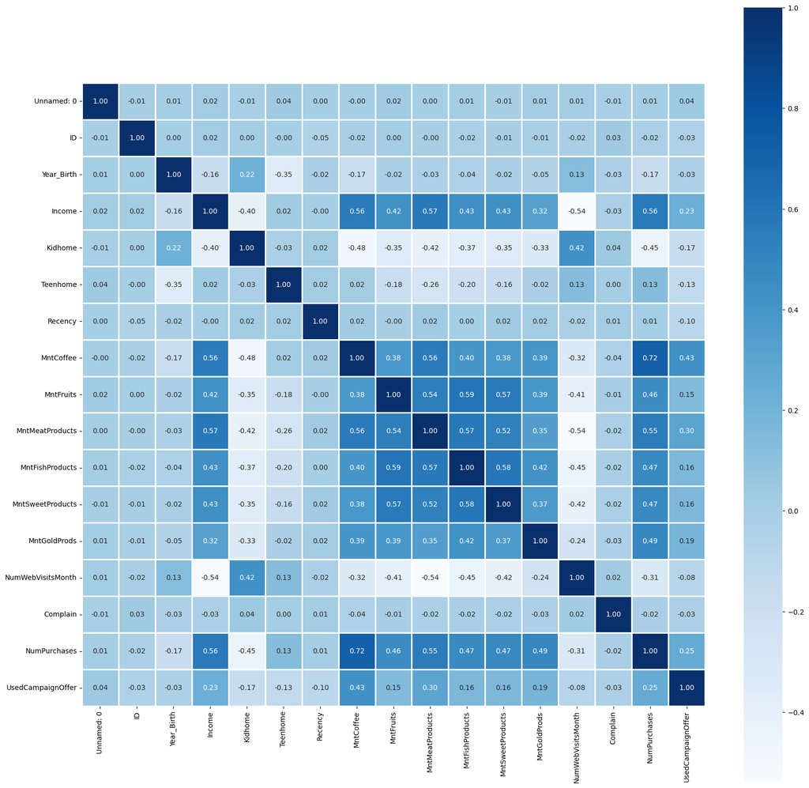

```python
plt.figure(figsize=(20, 20))
sns.heatmap(df.corr(numeric_only=True), annot=True, fmt=".2f", cmap="Blues", linewidths=1, square=True)
plt.show()
```

To get the features taht have the most correlation with the outcome, we can simply use the `df.corr()` with respect to the NumPurchases column.

```python
corr_array = (df.corr(numeric_only=True)["NumPurchases"].drop("NumPurchases")).sort_values(ascending=False)
corr_array
```

```
MntCoffee            0.715164
Income               0.562603
MntMeatProducts      0.554229
MntGoldProds         0.493939
MntSweetProducts     0.472876
MntFishProducts      0.469454
MntFruits            0.455461
UsedCampaignOffer    0.251386
Teenhome             0.133163
Unnamed: 0           0.007169
Recency              0.005740
Complain            -0.020583
ID                  -0.023834
Year_Birth          -0.168304
NumWebVisitsMonth   -0.309666
Kidhome             -0.447073
Name: NumPurchases, dtype: float64
```

As we can see, the features `MntCoffee` ,`Income` ,`MntMeatProducts` and `MntGoldProds` are the top four features related to the `NumPurchases`.

### Q4

```
MntCoffee             747
Income               1810
MntMeatProducts       558
MntGoldProds          212
MntSweetProducts      177
MntFishProducts       182
MntFruits             158
UsedCampaignOffer       2
Teenhome                3
Unnamed: 0           2240
Recency               100
Complain                2
ID                   2240
Year_Birth             59
NumWebVisitsMonth      15
Kidhome                 5
dtype: int64
```

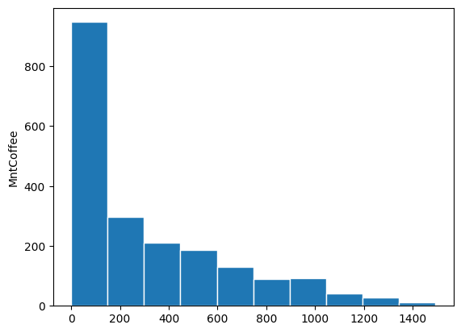

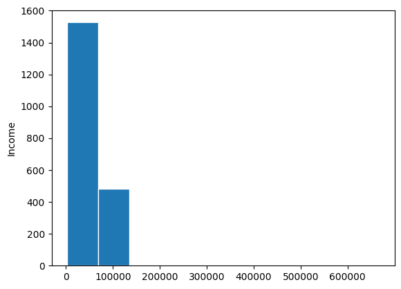

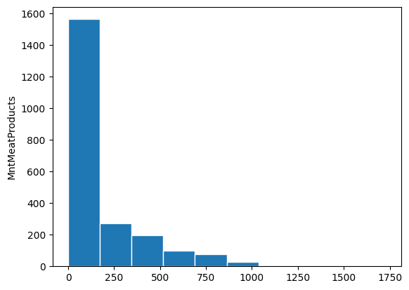

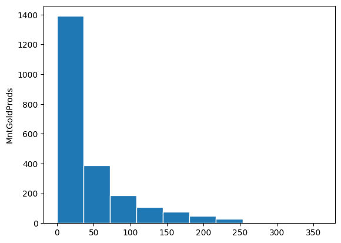

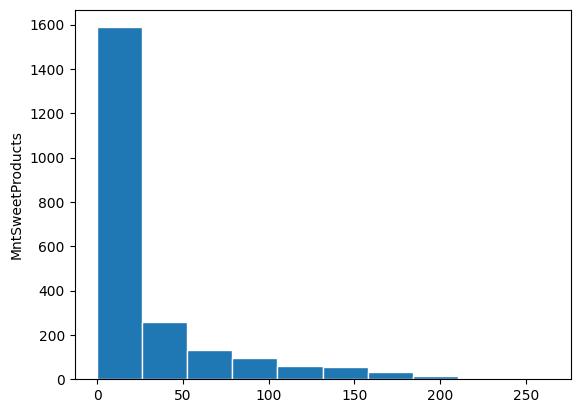

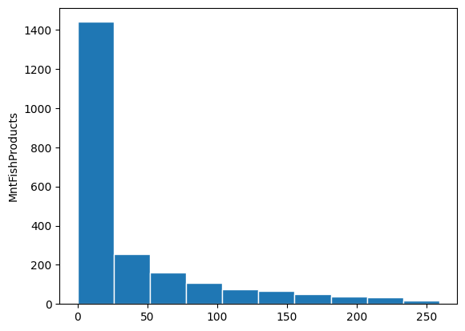

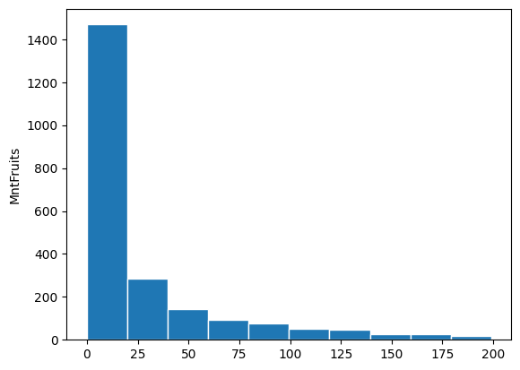

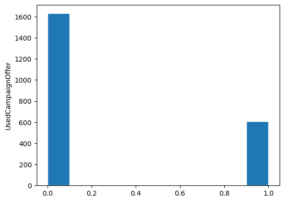

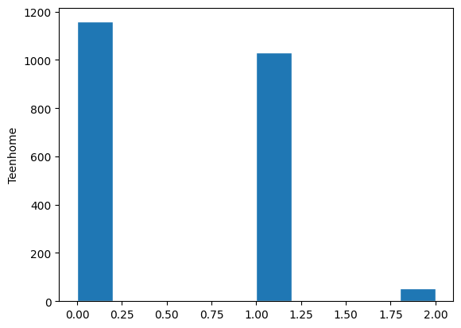

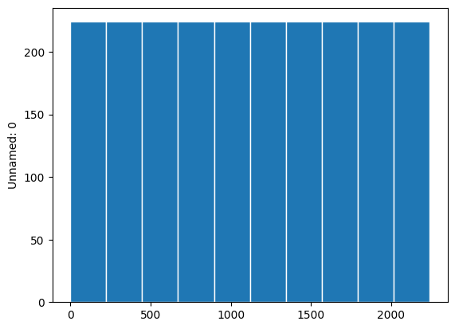

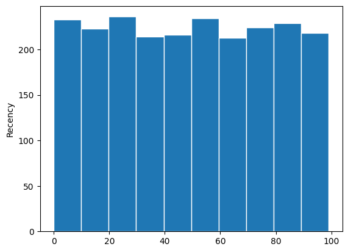

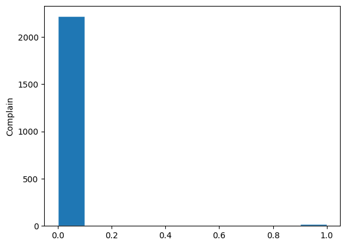

[4 more figures not shown]

```python
print(df[corr_array.index].nunique())

for feature in corr_array.index:
    plt.hist(df[feature], edgecolor='white')
    plt.ylabel(feature)
    plt.show()
```

### Q5

Here we use the function `plot_corr_scatter_hexbin` which gets the column we want to plot the scatter and hexbin, the datafarme, and the target column that we want to plot against.

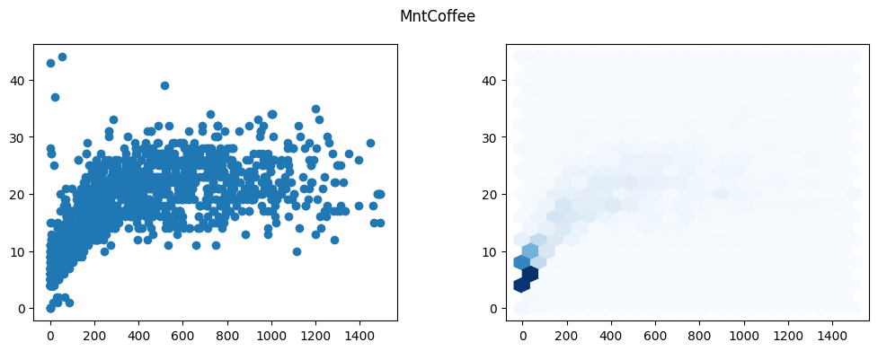

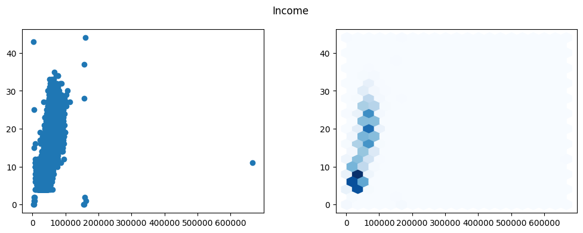

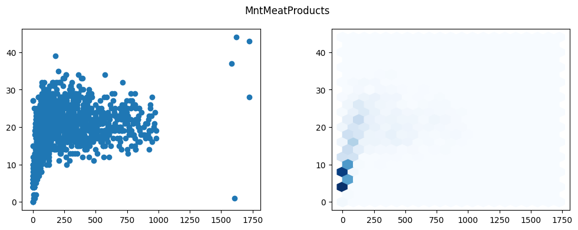

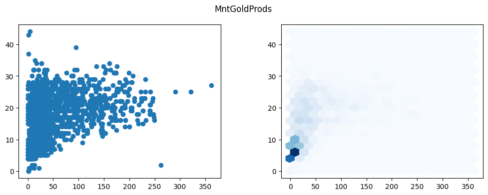

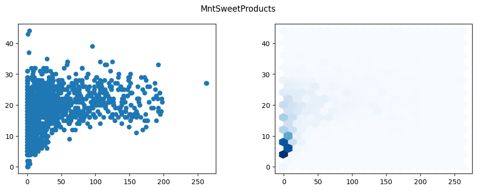

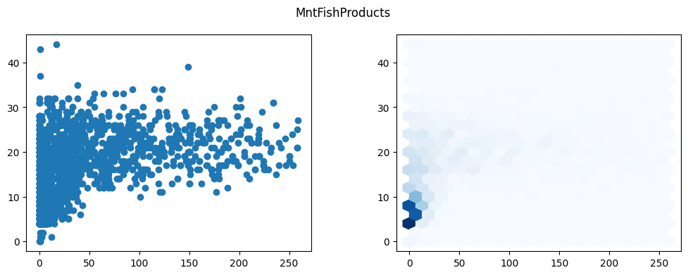

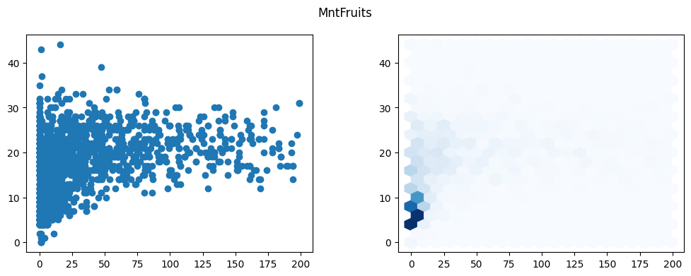

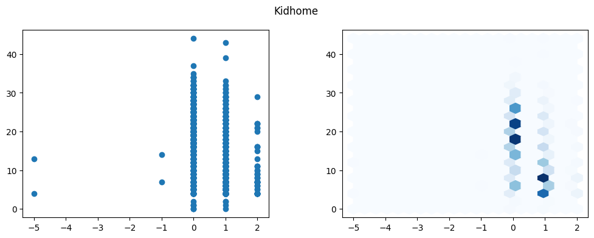

```python
for col in corr_array[abs(corr_array)>CORRELATION_THRESHOLD].index:
    plot_corr_scatter_hexbin(col,df,"NumPurchases")
```

## Preprocessing

First we need to mention that our data has some negative values that are not supposed to be negative. So we try to remove them.

```python
df.min()
```

```
Unnamed: 0                    0
ID                            0
Year_Birth                 1893
Education              2n Cycle
Marital_Status           Absurd
Income                   2447.0
Kidhome                      -5
Teenhome                      0
Dt_Customer          01-01-2013
Recency                       0
MntCoffee                   0.0
MntFruits                     0
MntMeatProducts               0
MntFishProducts               0
MntSweetProducts              0
MntGoldProds                0.0
NumWebVisitsMonth           0.0
Complain                      0
NumPurchases                  0
UsedCampaignOffer             0
dtype: object
```

As we can see the `Kidhome` column has negative value and it shouln't have.

```python
negative_columns = ["Kidhome"]
df[negative_columns] = np.where(df[negative_columns] < 0, np.nan, df[negative_columns])
```

### Q7

**Imputation:** is the process of replacing missing values with a substitution.

One such technique is mean imputation, where missing values are replaced by the mean value of the non-missing data. Similarly, the median and mode of the non-missing data could be used as a substitute. Alternatively, missing values could be replaced with the value of the previous or the next value or simply put a random value into the data.

- `Substitution with Mean`:  
  Using the average to fill missing values is simple to do and the mean is a good representation of the data. But sometimes it is impossible to use this for a column.
- `Substitution with Median`:  
  The outlier data can affect the mean negatively. So the median can be a good alternative in such cases.
- `Substitution with Mode`:  
  Mean and median do not work with categorical data. Using the mode can be a alternative for such data.
- `Random Substitution`:  
  In this method we fill using random values, mostly in the range of the column's minimum and maximum data, or between the categories.
- `Forward-fill and Backward-fill`:  
  In this method we fill the missing values with next or previous quantity.

A more advanced approach is an imputation method using model-based techniques, such as k-NN imputation or MICE (Multiple Imputation by Chained Equations). While the former fills the missing data based on the k nearest neighbors, the latter fits the observed data into a regression model before imputing missing values.

**Dropping**: Another option is to remove any observations that contain missing values. There are two main ways for this:

- `Dropping Columns`:  
  In this method we remove any column that has missing values. This method should only be considered on columns that have too many missing values Or we use a lot of data.
- `Dropping Rows`:  
  Works similarly to dropping columns.  
  If we remove all rows that have missing values, if a column is all missing, then all of the rows will be gone.  
  This method should also only be considered on rows that have most of their properties missing.

Finally, in some cases where missing data is limited, one could choose to ignore these values altogether and proceed with the analysis.

### Q8

```python
missing_values_count_and_percentage(df)
```

|  | Missing Count | Ratio |
| --- | --- | --- |
| Unnamed: 0 | 0 | 0.000000 |
| ID | 0 | 0.000000 |
| Year_Birth | 0 | 0.000000 |
| Education | 0 | 0.000000 |
| Marital_Status | 0 | 0.000000 |
| Income | 223 | 0.099554 |
| Kidhome | 4 | 0.001786 |
| Teenhome | 0 | 0.000000 |
| Dt_Customer | 0 | 0.000000 |
| Recency | 0 | 0.000000 |
| MntCoffee | 205 | 0.091518 |
| MntFruits | 0 | 0.000000 |
| MntMeatProducts | 0 | 0.000000 |
| MntFishProducts | 0 | 0.000000 |
| MntSweetProducts | 0 | 0.000000 |
| MntGoldProds | 13 | 0.005804 |
| NumWebVisitsMonth | 200 | 0.089286 |
| Complain | 0 | 0.000000 |
| NumPurchases | 0 | 0.000000 |
| UsedCampaignOffer | 0 | 0.000000 |

As we can see `Income`, `MntCoffee` and `NumWebVisitsMonth` has the most missing values.  
Here we use substitution with median to not get affected by outliers.

```python
df.fillna(df.median(numeric_only=True), inplace=True)
missing_values_count_and_percentage(df)
```

|  | Missing Count | Ratio |
| --- | --- | --- |
| Unnamed: 0 | 0 | 0.0 |
| ID | 0 | 0.0 |
| Year_Birth | 0 | 0.0 |
| Education | 0 | 0.0 |
| Marital_Status | 0 | 0.0 |
| Income | 0 | 0.0 |
| Kidhome | 0 | 0.0 |
| Teenhome | 0 | 0.0 |
| Dt_Customer | 0 | 0.0 |
| Recency | 0 | 0.0 |
| MntCoffee | 0 | 0.0 |
| MntFruits | 0 | 0.0 |
| MntMeatProducts | 0 | 0.0 |
| MntFishProducts | 0 | 0.0 |
| MntSweetProducts | 0 | 0.0 |
| MntGoldProds | 0 | 0.0 |
| NumWebVisitsMonth | 0 | 0.0 |
| Complain | 0 | 0.0 |
| NumPurchases | 0 | 0.0 |
| UsedCampaignOffer | 0 | 0.0 |

```python
df.describe()
```

|  | Unnamed: 0 | ID | Year_Birth | Income | Kidhome | Teenhome | Recency | MntCoffee | MntFruits | MntMeatProducts | MntFishProducts | MntSweetProducts | MntGoldProds | NumWebVisitsMonth | Complain | NumPurchases | UsedCampaignOffer |
| --- | --- | --- | --- | --- | --- | --- | --- | --- | --- | --- | --- | --- | --- | --- | --- | --- | --- |
| count | 2240.000000 | 2240.000000 | 2240.000000 | 2240.000000 | 2240.000000 | 2240.000000 | 2240.000000 | 2240.000000 | 2240.000000 | 2240.000000 | 2240.000000 | 2240.000000 | 2240.000000 | 2240.000000 | 2240.000000 | 2240.000000 | 2240.000000 |
| mean | 1119.500000 | 5592.159821 | 1968.805804 | 52204.686607 | 0.443304 | 0.506250 | 49.109375 | 292.594643 | 26.302232 | 166.950000 | 37.525446 | 27.062946 | 43.732589 | 5.387054 | 0.009375 | 14.862054 | 0.271875 |
| std | 646.776623 | 3246.662198 | 11.984069 | 24239.324425 | 0.538305 | 0.544538 | 28.962453 | 323.779750 | 39.773434 | 225.715373 | 54.628979 | 41.280498 | 51.768185 | 2.335755 | 0.096391 | 7.677173 | 0.445025 |
| min | 0.000000 | 0.000000 | 1893.000000 | 2447.000000 | 0.000000 | 0.000000 | 0.000000 | 0.000000 | 0.000000 | 0.000000 | 0.000000 | 0.000000 | 0.000000 | 0.000000 | 0.000000 | 0.000000 | 0.000000 |
| 25% | 559.750000 | 2828.250000 | 1959.000000 | 36925.500000 | 0.000000 | 0.000000 | 24.000000 | 27.000000 | 1.000000 | 16.000000 | 3.000000 | 1.000000 | 9.000000 | 4.000000 | 0.000000 | 8.000000 | 0.000000 |
| 50% | 1119.500000 | 5458.500000 | 1970.000000 | 51369.000000 | 0.000000 | 0.000000 | 49.000000 | 177.000000 | 8.000000 | 67.000000 | 12.000000 | 8.000000 | 24.000000 | 6.000000 | 0.000000 | 15.000000 | 0.000000 |
| 75% | 1679.250000 | 8427.750000 | 1977.000000 | 66387.750000 | 1.000000 | 1.000000 | 74.000000 | 459.000000 | 33.000000 | 232.000000 | 50.000000 | 33.000000 | 56.000000 | 7.000000 | 0.000000 | 21.000000 | 1.000000 |
| max | 2239.000000 | 11191.000000 | 1996.000000 | 666666.000000 | 2.000000 | 2.000000 | 99.000000 | 1493.000000 | 199.000000 | 1725.000000 | 259.000000 | 263.000000 | 362.000000 | 20.000000 | 1.000000 | 44.000000 | 1.000000 |

As we `describe` the new dataframe `mean` and `std` are pretty close to the not changed dataframe so we can see that the method we chose hasn't changed our dataset dramaticaly.

As an alternative method we could have delete rows that have more than zero NaN values, and then use KNNImputer to fill them.

### Q9

Normalization is a technique used to standardize the range of values of numerical features in a dataset. It is a common preprocessing step in machine learning and data analysis to ensure that different features are on a similar scale, which can help improve the performance of certain algorithms. For example, we can scale the values of the features to the range of [0, 1] or [-1, 1]. This method is useful when we have no outliers and the data lies in a fixed range. We can use the `MinMaxScaler` method to do this. Below is the formula for the `MinMaxScaler` method:

$$X_{norm} = \frac{X - X_{min}}{X_{max} - X_{min}}$$

Normalization is a good technique to use when you do not know the distribution of your data or when you know the distribution is not Gaussian. Normalization is useful when your data has varying scales and the algorithm you are using does not make assumptions about the distribution of your data.

Standardization is a technique used to transform numerical data to have a mean of 0 and a standard deviation of 1. We can use the `StandardScaler` method to do this. Below is the formula for the `StandardScaler` method:

$$X_{std} = \frac{X - \mu}{\sigma}$$

Standardization assumes that your data has a Gaussian distribution. This does not strictly have to be true, but the technique is more effective if your attribute distribution is Gaussian. Standardization is useful when your data has varying scales and the algorithm you are using does make assumptions about your data having a Gaussian distribution, such as linear regression, logistic regression, and linear discriminant analysis.

Now lets see which of the standardization and normalization we need.

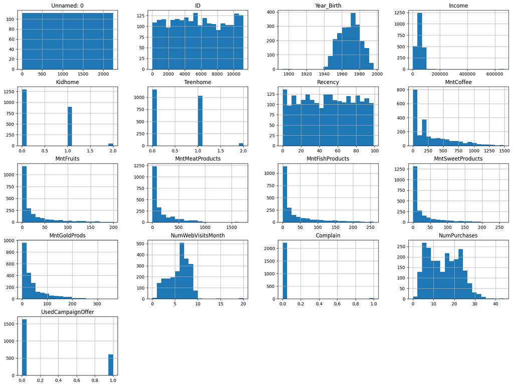

```python
df.hist(bins=20, figsize=(20,15))
plt.show()
```

Since the features with the most correlation are a bit away from Gaussian distribution we use normalization. we also use standardization because it causes our ML models to converge easier.

Here we define the `Scaler` class which can do the standardization and normalization.

```python
class Scaler:
    def __init__(self, df):
        self.df = df
        self.numeric_cols = df.select_dtypes(include="number")
        self.std = StandardScaler()
        self.norm = MinMaxScaler()

    def standardization(self, exclude_cols):
        self.df[self.numeric_cols.columns] = self.std.fit_transform(self.numeric_cols)
        self.df[exclude_cols] = self.numeric_cols[exclude_cols]

    def normalization(self, exclude_cols):
        self.df[self.numeric_cols.columns] = self.norm.fit_transform(self.numeric_cols)
        self.df[exclude_cols] = self.numeric_cols[exclude_cols]
```

```python
scalar = Scaler(df)
scalar.normalization(exclude_cols=["NumPurchases"])
scalar.standardization(exclude_cols=["NumPurchases"])
scalar.df.describe()
```

|  | Unnamed: 0 | ID | Year_Birth | Income | Kidhome | Teenhome | Recency | MntCoffee | MntFruits | MntMeatProducts | MntFishProducts | MntSweetProducts | MntGoldProds | NumWebVisitsMonth | Complain | NumPurchases | UsedCampaignOffer |
| --- | --- | --- | --- | --- | --- | --- | --- | --- | --- | --- | --- | --- | --- | --- | --- | --- | --- |
| count | 2240.000000 | 2.240000e+03 | 2.240000e+03 | 2.240000e+03 | 2.240000e+03 | 2.240000e+03 | 2.240000e+03 | 2.240000e+03 | 2.240000e+03 | 2.240000e+03 | 2.240000e+03 | 2.240000e+03 | 2.240000e+03 | 2.240000e+03 | 2.240000e+03 | 2240.000000 | 2.240000e+03 |
| mean | 0.000000 | 2.220446e-17 | -8.133970e-15 | -9.992007e-17 | 9.992007e-17 | -3.172066e-18 | -3.172066e-18 | 3.172066e-17 | -2.379049e-17 | 4.123686e-17 | 1.506731e-17 | -1.506731e-17 | 3.489272e-17 | 1.839798e-16 | -3.053113e-17 | 14.862054 | 3.806479e-17 |
| std | 1.000223 | 1.000223e+00 | 1.000223e+00 | 1.000223e+00 | 1.000223e+00 | 1.000223e+00 | 1.000223e+00 | 1.000223e+00 | 1.000223e+00 | 1.000223e+00 | 1.000223e+00 | 1.000223e+00 | 1.000223e+00 | 1.000223e+00 | 1.000223e+00 | 7.677173 | 1.000223e+00 |
| min | -1.731278 | -1.722818e+00 | -6.326960e+00 | -2.053225e+00 | -8.237017e-01 | -9.298944e-01 | -1.696001e+00 | -9.038860e-01 | -6.614492e-01 | -7.398135e-01 | -6.870680e-01 | -6.557331e-01 | -8.449660e-01 | -2.306859e+00 | -9.728167e-02 | 0.000000 | -6.110569e-01 |
| 25% | -0.865639 | -8.514982e-01 | -8.184192e-01 | -6.304878e-01 | -8.237017e-01 | -9.298944e-01 | -8.671566e-01 | -8.204773e-01 | -6.363012e-01 | -6.689119e-01 | -6.321399e-01 | -6.315032e-01 | -6.710752e-01 | -5.939679e-01 | -9.728167e-02 | 8.000000 | -6.110569e-01 |
| 50% | 0.000000 | -4.117757e-02 | 9.967091e-02 | -3.448418e-02 | -8.237017e-01 | -9.298944e-01 | -3.777284e-03 | -3.570960e-01 | -4.602650e-01 | -4.429132e-01 | -4.673554e-01 | -4.618937e-01 | -3.812572e-01 | 2.624776e-01 | -9.728167e-02 | 15.000000 | -6.110569e-01 |
| 75% | 0.865639 | 8.735813e-01 | 6.839101e-01 | 5.852568e-01 | 1.034397e+00 | 9.069340e-01 | 8.596020e-01 | 5.140609e-01 | 1.684356e-01 | 2.882592e-01 | 2.284015e-01 | 1.438543e-01 | 2.370211e-01 | 6.907003e-01 | -9.728167e-02 | 21.000000 | 1.636509e+00 |
| max | 1.731278 | 1.724876e+00 | 2.269702e+00 | 2.535543e+01 | 2.892495e+00 | 2.743762e+00 | 1.722981e+00 | 3.708303e+00 | 4.343008e+00 | 6.904261e+00 | 4.055064e+00 | 5.716737e+00 | 6.149307e+00 | 6.257596e+00 | 1.027943e+01 | 44.000000 | 1.636509e+00 |

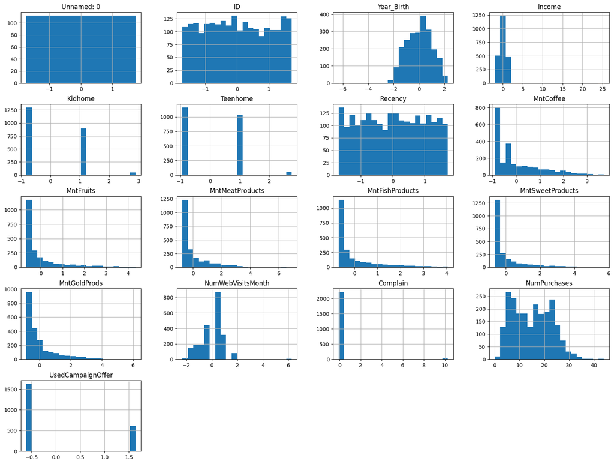

```python
df=scalar.df
df.hist(bins=20, figsize=(20,15))
plt.show()
```

### Q10

There are many ways to encode the categorical features. Some of them are as follows:

- `One-Hot Encoding`: This method creates binary columns for each category in a categorical feature. Each column represents the presence or absence of a specific category, and only one column can have a value of 1 for each sample.
- `Label Encoding`: Label encoding assigns a unique integer value to each category in a categorical feature. Each category is mapped to a numerical label, allowing the model to understand the ordinal relationship between categories.
- `Ordinal Encoding`: Similar to label encoding, ordinal encoding assigns numerical labels to categories. However, in ordinal encoding, the labels are assigned based on the order or rank of the categories.
- `Count Encoding`: Count encoding replaces each category with the count of occurrences of that category in the dataset. It encodes categories based on their frequency and can be useful when the frequency of categories carries important information.
- `Target Encoding`: Target encoding replaces each category with the mean of the target variable for that category.
- `Frequency Encoding`: Frequency encoding replaces each category with the frequency or proportion of that category in the dataset.
- `Binary Encoding`: Binary encoding represents each category with binary digits. Each category is first assigned an ordinal label, which is then converted into binary representation. Binary encoding reduces the dimensionality compared to one-hot encoding while preserving some information about the categories.
- `Hash Encoding`: Hash encoding applies a hashing function to map categories to a fixed number of values. It reduces the dimensionality of the feature space but may introduce collisions.
- `Text Encoding`: Categorical features are often stored as text. Before using them in model training, you can convert these texts into numerical representations such as TF-IDF vectors or Word2Vec embeddings.

Here for encoding we use `Label Encoding` as I don't want to increase the dimensions of the dataset.

```python
cat_cols=df.select_dtypes(include=["category", "object"])
df[cat_cols.columns] = category_encoders.OrdinalEncoder(cols=cat_cols.columns).fit_transform(cat_cols)
display(df)
```

|  | Unnamed: 0 | ID | Year_Birth | Education | Marital_Status | Income | Kidhome | Teenhome | Dt_Customer | Recency | MntCoffee | MntFruits | MntMeatProducts | MntFishProducts | MntSweetProducts | MntGoldProds | NumWebVisitsMonth | Complain | NumPurchases | UsedCampaignOffer |
| --- | --- | --- | --- | --- | --- | --- | --- | --- | --- | --- | --- | --- | --- | --- | --- | --- | --- | --- | --- | --- |
| 0 | -1.731278 | -0.020999 | -0.985345 | 1 | 1 | 0.244835 | -0.823702 | -0.929894 | 1 | 0.307039 | 1.057762 | 1.551577 | 1.679702 | 2.462147 | 1.476500 | 0.855299 | 0.262478 | -0.097282 | 25 | 1.636509 |
| 1 | -1.729731 | -1.053058 | -1.235733 | 1 | 1 | -0.241838 | 1.034397 | 0.906934 | 2 | -0.383664 | -0.357096 | -0.636301 | -0.713225 | -0.650449 | -0.631503 | -0.729039 | -0.165745 | -0.097282 | 6 | -0.611057 |
| 2 | -1.728185 | -0.447070 | -0.317643 | 1 | 2 | 0.800874 | -0.823702 | -0.929894 | 3 | -0.798086 | -0.357096 | 0.570804 | -0.177032 | 1.345274 | -0.146905 | -0.033476 | 0.262478 | -0.097282 | 21 | -0.611057 |
| 3 | -1.726638 | 0.181716 | 1.268149 | 1 | 2 | -1.054666 | 1.034397 | -0.929894 | 4 | -0.798086 | -0.869905 | -0.560857 | -0.651187 | -0.503974 | -0.583043 | -0.748360 | 0.262478 | -0.097282 | 8 | -0.611057 |
| 4 | -1.725092 | -0.082614 | 1.017761 | 2 | 3 | 0.251231 | 1.034397 | -0.929894 | 5 | 1.550305 | -0.369453 | 0.419916 | -0.216914 | 0.155164 | -0.001525 | -0.555148 | -0.165745 | -0.097282 | 19 | -0.611057 |
| ... | ... | ... | ... | ... | ... | ... | ... | ... | ... | ... | ... | ... | ... | ... | ... | ... | ... | ... | ... | ... |
| 2235 | 1.725092 | 1.625983 | -0.150717 | 1 | 3 | 0.372136 | -0.823702 | 0.906934 | 226 | -0.107383 | 1.286363 | 0.419916 | 0.066692 | 0.081926 | 2.203398 | 3.927370 | -0.165745 | -0.097282 | 18 | -0.611057 |
| 2236 | 1.726638 | -0.490200 | -1.903435 | 2 | 2 | 0.487305 | 2.892495 | 0.906934 | 575 | 0.237969 | 0.350333 | -0.661449 | -0.606873 | -0.687068 | -0.655733 | -0.690396 | 0.690700 | -0.097282 | 22 | 1.636509 |
| 2237 | 1.728185 | 0.516905 | 1.017761 | 1 | 4 | 0.197092 | -0.823702 | -0.929894 | 441 | 1.446700 | 1.901116 | 0.545656 | 0.221789 | -0.101168 | -0.364974 | -0.381257 | 0.262478 | -0.097282 | 19 | 1.636509 |
| 2238 | 1.729731 | 0.814199 | -1.068807 | 3 | 2 | 0.703160 | -0.823702 | 0.906934 | 103 | -1.419719 | 0.418295 | 0.092992 | 0.208495 | 0.777683 | 0.071165 | 0.333627 | 0.262478 | -0.097282 | 23 | -0.611057 |
| 2239 | 1.731278 | 1.174650 | -1.235733 | 2 | 3 | 0.027413 | 1.034397 | 0.906934 | 215 | -0.314594 | -0.644392 | -0.586005 | -0.469501 | -0.650449 | -0.631503 | -0.439221 | 0.690700 | -0.097282 | 11 | 1.636509 |

2240 rows × 20 columns

### Q11

```python
df=df[corr_array[abs(corr_array)>CORRELATION_THRESHOLD].index.union(["NumPurchases"])]
df.head(10)
```

|  | Income | Kidhome | MntCoffee | MntFishProducts | MntFruits | MntGoldProds | MntMeatProducts | MntSweetProducts | NumPurchases |
| --- | --- | --- | --- | --- | --- | --- | --- | --- | --- |
| 0 | 0.244835 | -0.823702 | 1.057762 | 2.462147 | 1.551577 | 0.855299 | 1.679702 | 1.476500 | 25 |
| 1 | -0.241838 | 1.034397 | -0.357096 | -0.650449 | -0.636301 | -0.729039 | -0.713225 | -0.631503 | 6 |
| 2 | 0.800874 | -0.823702 | -0.357096 | 1.345274 | 0.570804 | -0.033476 | -0.177032 | -0.146905 | 21 |
| 3 | -1.054666 | 1.034397 | -0.869905 | -0.503974 | -0.560857 | -0.748360 | -0.651187 | -0.583043 | 8 |
| 4 | 0.251231 | 1.034397 | -0.369453 | 0.155164 | 0.419916 | -0.555148 | -0.216914 | -0.001525 | 19 |
| 5 | -0.034484 | -0.823702 | 0.702503 | -0.687068 | 0.394768 | -0.574469 | -0.305541 | 0.361924 | 22 |
| 6 | 0.141550 | -0.823702 | -0.177922 | 0.228401 | 0.973172 | -0.323294 | -0.013072 | 0.531533 | 21 |
| 7 | -0.773737 | 1.034397 | -0.669106 | -0.632140 | -0.409969 | -0.400578 | -0.491658 | -0.631503 | 10 |
| 8 | -0.901781 | 1.034397 | -0.860637 | -0.632140 | -0.661449 | -0.806324 | -0.633461 | -0.583043 | 6 |
| 9 | -1.921138 | 1.034397 | -0.817388 | -0.668759 | -0.661449 | -0.593790 | -0.713225 | -0.631503 | 2 |

### Q12

There are some ways to split the dataset into train and test sets. Some of them are as follows:

- `Holdout Method`: In this method, a percentage of the data, is randomly assigned to the training set, and the remaining percentage is allocated to the test set.
- `Cross-Validation`: Cross-validation is a technique where the data is divided into multiple subsets or folds. The model is trained and evaluated multiple times, with each fold used as the test set once and the rest as the training set.
  - K-Fold Cross-Validation: The data is divided into K subsets of approximately equal size. The model is trained and evaluated K times, with each fold used as the test set once. The final performance is averaged over the K iterations.
  - Stratified K-Fold Cross-Validation: This method is similar to K-Fold, but it ensures that the distribution of target classes remains consistent across each fold. This is particularly useful when dealing with imbalanced datasets.
- `Leave-One-Out Cross-Validation`: Here, each data point is used as the test set, and the rest of the data is used for training. This method is computationally expensive for large datasets but can provide an unbiased evaluation.
- `Time-based Split`: This method is useful when we have a time series dataset. But it is not useful in this case.

```python
features = df.drop("NumPurchases", axis = "columns")
X_train, X_test, y_train, y_test = train_test_split(features, df["NumPurchases"], test_size=0.2, random_state=42)
```

### Q13

Validation data in machine learning is a subset of labeled data that is used to evaluate the performance of a trained model. It helps in adjusting model settings to improve generalization and prevent overfitting. The data should be representative of real-world scenarios and is separate from the training and test data.

### Q14

The process works as follows:

- The data is divided into k equal-sized subsets.
- The model is trained k times, each time using k-1 folds as training data and one fold as validation data.
- The performance of the model is evaluated on the validation set for each iteration.
- The final performance metric is usually an average of the performance across all k iterations.

K-fold cross-validation provides a more robust estimate of a model's performance compared to a single train-validation split. It helps to ensure that the model's evaluation is not dependent on a specific random split of the data, as it evaluates the model on different subsets of the data.

## Training, Testing and Evaluating the Models.

### 1. Linear Regression

### Q15

Main form of simple linear regression function: $$f(x) = \alpha x + \beta$$

- step 1: Compute RSS of the training data

$$ RSS = \Sigma (y_i - (\hat{\beta} + \hat{\alpha} * x_i) )^2 $$

- step 2: Compute the derivatives of the RSS function in term of $\underline{\alpha}$ and $\underline{\beta}$, and set them equal to 0 to find the desired parameters

$$ \frac{\partial RSS}{\partial \beta} = \Sigma (-f(x_i) + \hat{\beta} + \hat{\alpha} * x_i) = 0$$ $$ \to \hat{\beta} = \hat{y} - \hat{\alpha} \hat{x} \to (1)$$

$$ \frac{\partial RSS}{\partial \alpha} = \Sigma (-2 x_i y_i + 2 \hat{\beta} x_i + 2\hat{\alpha} x_i ^ 2) = 0 \to (2)$$

$$ (1) , (2) \to \hat{\alpha} = \frac{\Sigma{(x_i - \hat{x})(y_i - \hat{y})}}{\Sigma{(x_i - \hat{x})^2}} $$ $$ \hat{\beta} = \hat{y} - \hat{\alpha} \hat{x}$$

### Q16

We pick the `MntCoffee` feature as the main feature here because it has the highest correlation.

Based on the above formula, implement the function below to compute the parameters of a simple linear regression

```python
def simple_linear_regression(input_feature, output):
    Sxy = (input_feature * output).sum() - input_feature.sum() * output.sum() / len(output)
    Sxx = (input_feature ** 2).sum() - (input_feature.sum())**2 / len(output)
    slope = Sxy / Sxx
    intercept = output.mean() - slope * input_feature.mean()
    return (intercept, slope)
```

Now complete this `get_regression_predictions(...)` function to predict the value of given data based on the calculated intercept and slope

```python
def get_regression_predictions(input_feature, intercept, slope):
    return intercept + slope * input_feature
```

### Q17

`Residual Sum of Squares (RSS)`: The RSS is the sum of the squared differences between the predicted values and the actual values. It measures the total amount of error in the model.  
`Mean Squared Error (MSE)`: The MSE is the average of the squared differences between the predicted values and the actual values. It measures the average amount of error in the model.  
`Root Mean Squared Error (RMSE)`: The RMSE is the square root of the MSE. It measures the average amount of error in the model in the same units as the dependent variable.  
`R-squared (R2) score`: The R2 score is a measure of how well the model fits the data. It represents the proportion of the variance in the dependent variable that is explained by the independent variables. The R2 score ranges from 0 to 1, with higher values indicating a better fit.  
The R2 score is calculated by comparing the sum of the squared differences between the actual and predicted values of the dependent variable to the total sum of squared differences between the actual and mean values of the dependent variable. Matematically, the R2 score formula is shown as follows:

$$R^2 = 1 - \frac{SSres}{SStot} = 1 - \frac{\sum_{i=1}^{n} (y_{i,true} - y_{i,pred})^2}{\sum_{i=1}^{n} (y_{i,true} - \bar{y}_{true})^2} $$

### Q18

```python
def get_root_mean_square_error(predicted_values, output):
    residuals = output - predicted_values

    residuals_squared_sum = np.sum(residuals ** 2)

    mean_residuals_squared = residuals_squared_sum / len(output)

    RMSE = np.sqrt(mean_residuals_squared)

    return RMSE
```

```python
def get_r2_score(predicted_values, output):
    residuals = output - predicted_values

    SSres = np.sum(residuals ** 2)

    SStot = np.sum((output - np.mean(output)) ** 2)

    R2_score = 1 - SSres / SStot

    return R2_score
```

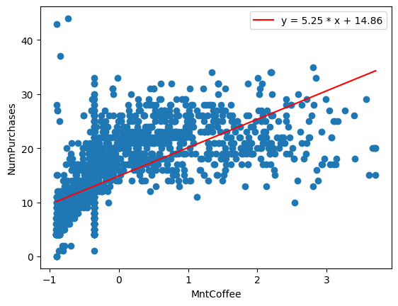

```
Feature  : MntCoffee
RMSE     : 5.478181136735979
R2 Score : 0.46894841333560877
--------------------------------------------
```

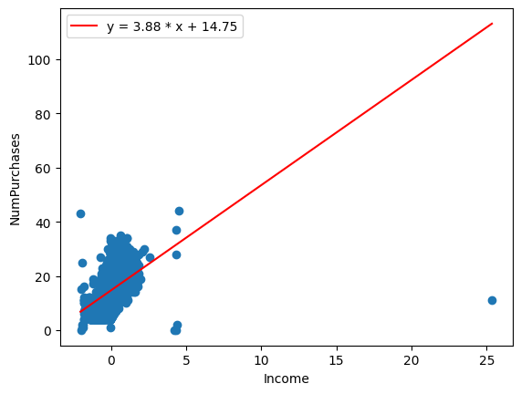

```
Feature  : Income
RMSE     : 6.148967303526898
R2 Score : 0.33093501514415213
--------------------------------------------
```

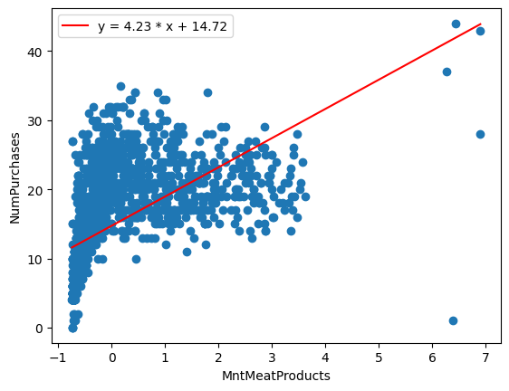

```
Feature  : MntMeatProducts
RMSE     : 6.372102330648993
R2 Score : 0.28149562382265725
--------------------------------------------
```

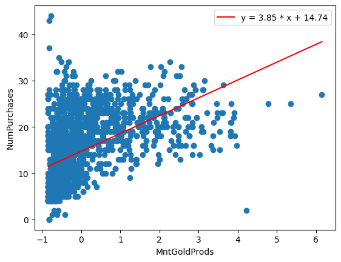

```
Feature  : MntGoldProds
RMSE     : 6.750622450723992
R2 Score : 0.193598042605984
--------------------------------------------
```

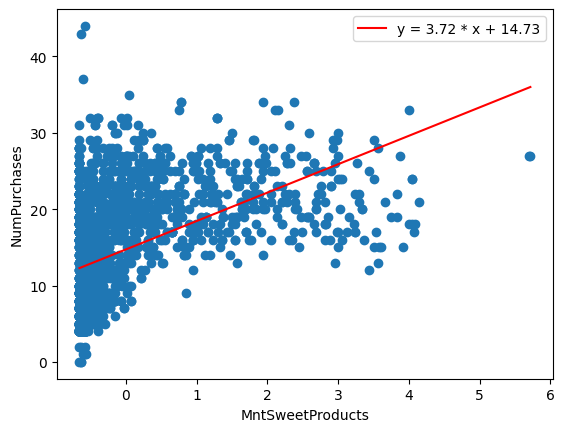

```
Feature  : MntSweetProducts
RMSE     : 6.8195203596319125
R2 Score : 0.17705351415109472
--------------------------------------------
```

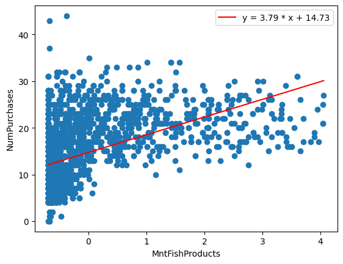

```
Feature  : MntFishProducts
RMSE     : 7.030343098976953
R2 Score : 0.12538489223606364
--------------------------------------------
```

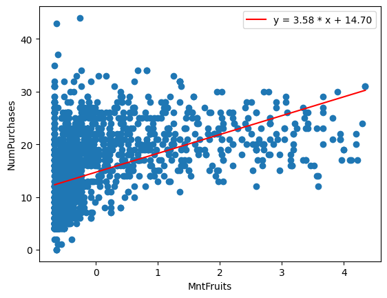

```
Feature  : MntFruits
RMSE     : 6.98610944562422
R2 Score : 0.13635611051223984
--------------------------------------------
```

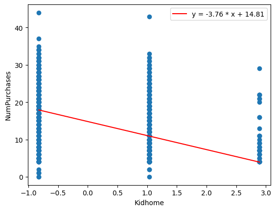

```
Feature  : Kidhome
RMSE     : 6.935114219405048
R2 Score : 0.14891845990808217
--------------------------------------------
```

```python
designated_feature_list = list(corr_array[abs(corr_array)>CORRELATION_THRESHOLD].index)

for feature in designated_feature_list:
    intercept, slope = simple_linear_regression(X_train[feature], y_train)
    predicted_values = get_regression_predictions(X_test[feature], intercept, slope)
    plot_simple_reg_line(X_train[feature],y_train,slope,intercept,feature)
    RMSE = get_root_mean_square_error(predicted_values, y_test)
    R2_score = get_r2_score(predicted_values, y_test)

    print("Feature  :", feature)
    print("RMSE     :", RMSE)
    print("R2 Score :", R2_score)
    print("--------------------------------------------")
```

linear regression tends to perform well when the relationship between the independent and dependent variables is linear and there is little noise or variability in the data.

However, if the relationship between the variables is non-linear or there is a lot of noise in the data, linear regression may not be the best choice and other models may be more appropriate.

Overall, the R2 scores for all the models are relatively low, which suggests that the independent variables may not be very good predictors of the dependent variable.

### 2. Multiple Regression

Multiple regression is a statistical technique that aims to model the relationship between a dependent variable and two or more independent variables.

Multiple regression with n independent variables is expressed as follows:

$$f(x) = \beta _{0} + \beta_{1} x_{1} + \beta_{2} x_{2} + \beta_{3} x_{3} + \beta_{4} x_{4} + ... + \beta_{n} x_{n} + c $$

To optimize the model for accurate predictions, multiple regression commonly employs iterative algorithms such as gradient descent.

The main goal of the optimization process is to make our predictions as close as possible to the actual values. We measure the prediction error using a cost function, usually denoted as $J(\beta)$.

$$ J(\beta)= \frac {1}{2m} Σ_{i=0}^{m-1}(y_i - (\hat \beta _{0} + \hat \beta_{1} x_{1} + \hat \beta_{2} x_{2} + \hat \beta_{3} x_{3} + \hat \beta_{4} x_{4} + ... + \hat \beta_{n} x_{n}) )^2 $$

Gradient descent iteratively adjusts the coefficients $(\beta_i)$ to minimize the cost function. The update rule for each coefficient is:

$$\beta_{i} = \beta _ {i} - \alpha \frac {∂J(\beta)}{∂\beta_{i}}$$

$$ \frac {∂J(\beta)}{∂\beta_{i}} = \frac {1}{m}Σ_{j=0}^{m-1}(y_j - (\hat \beta _{0} + \hat \beta_{1} x_{j1} + \hat \beta_{2} x_{j2} + \hat \beta_{3} x_{j3} + \hat \beta_{4} x_{j4} + ... + \hat \beta_{n} x_{jn})) x_{ji} $$

### Predicting output given regression weights

Based on the formula above and [np.dot()](https://numpy.org/doc/stable/reference/generated/numpy.dot.html) method, complete this function to compute the predictions for an entire matrix of features given the matrix, bias, and the weights. Provide an explanation of np.dot method and the reasoning behind using this method in your code:

The `dot` product is a mathematical operation between two vectors that results in a scalar value. we can perform this operation in NumPy using `np.dot()`. for prediction we use this formula: $$\hat{Y} = X\beta + b$$ and because both $X$ and $\beta$ are vectors we use the `np.dot`.

```python
def predict_output(feature_matrix, weights, bias):
    prediction = np.dot(feature_matrix, weights)
    prediction += bias

    return prediction
```

### Computing the Derivative

As we saw, the cost function is the sum over the data points of the squared difference between an observed output and a predicted output.

Since the derivative of a sum is the sum of the derivatives, we can compute the derivative for a single data point and then sum over data points. We can write the squared difference between the observed output and predicted output for a single point as follows:

$$ (output - (const* w _{0} + [feature_1] * w_{1} + ...+ [feature_n] * w_{n} ))^2 $$

With n feautures and a const , So the derivative will be :

$$ 2 * (output - (const* w _{0} + [feature_1] * w_{1} + ...+ [feature_n] * w_{n} )) $$

The term inside the paranethesis is just the error (difference between prediction and output). So we can re-write this as:

$$2 * error*[feature_i] $$

That is, the derivative for the weight for feature i is the sum (over data points) of 2 times the product of the error and the feature itself. In the case of the constant then this is just twice the sum of the errors!

Recall that twice the sum of the product of two vectors is just twice the dot product of the two vectors. Therefore the derivative for the weight for feature_i is just two times the dot product between the values of feature_i and the current errors.

With this in mind, complete the following derivative function which computes the derivative of the weight given the value of the feature (over all data points) and the errors (over all data points).

```python
def feature_derivative(errors, feature):
    feature_derivative = 2 * np.dot(errors, feature)
    return feature_derivative
```

### Gradient Descent

Now we will write a function that performs a gradient descent. The basic premise is simple. Given a starting point we update the current weights by moving in the negative gradient direction. Recall that the gradient is the direction of increase and therefore the negative gradient is the direction of decrease and we're trying to minimize a cost function.

The amount by which we move in the negative gradient direction is called the 'step size'. We stop when we are 'sufficiently close' to the optimum. We define this by requiring that the magnitude (length) of the gradient vector to be smaller than a fixed 'tolerance'.

With this in mind, complete the following gradient descent function below using your derivative function above. For each step in the gradient descent we update the weight for each feature befofe computing our stopping criteria.

```python
def regression_gradient_descent(feature_matrix, outputs, initial_weights, bias, step_size, tolerance):
    weights = np.array(initial_weights)
    converged = False
    while not converged:
        predictions = predict_output(feature_matrix, weights, bias)
        errors = outputs - predictions

        gradient = - feature_derivative(feature_matrix.T, errors)
        weights -= step_size * gradient

        bias_gradient = -2 * np.sum(errors)
        bias -= step_size * bias_gradient

        if np.linalg.norm(gradient) < tolerance:
            converged = True

    return weights, bias
```

```python
# Utility functions for multiple regression

def normalize_features(chosen_features, data_frame):
    for feature in chosen_features:
        data_frame[feature] = (data_frame[feature] - data_frame[feature].mean()) / data_frame[feature].std()
    return data_frame


def n_feature_regression(chosen_feature_matrix, target_matrix, keywords):
    initial_weights = keywords['initial_weights']
    step_size = keywords['step_size']
    tolerance = keywords['tolerance']
    bias = keywords['bias']

    weights, bias = regression_gradient_descent(chosen_feature_matrix, target_matrix, initial_weights, bias, step_size,
                                                tolerance)

    return weights, bias

def get_weights_and_bias(chosen_features):
    """
    Computes the weights and bias for a general n feature model.
    :param chosen_features:  list of features to perform multiple regression on
    :return: chosen_feature_matrix, computed weights and bias via regression
    """


    keywords = {
        'initial_weights': np.array([.5]*len(chosen_features)),
        'step_size': 1.e-4,
        'tolerance': 1.e-10,
        'bias': 0
    }

    chosen_feature_dataframe = X_train[chosen_features]
    # chosen_feature_dataframe = normalize_features(chosen_features, chosen_feature_dataframe)
    chosen_feature_matrix = chosen_feature_dataframe.to_numpy()

    target_column = y_train
    target_matrix = target_column.to_numpy()

    train_weights, bias = n_feature_regression(chosen_feature_matrix, target_matrix, keywords)

    return chosen_feature_matrix, train_weights, bias
```

- Would selecting different initial weights make any difference? Explain your answer.
- Yes, selecting different initial weights in a multiple regression problem can make a difference. The choice of initial weights affects the starting point for the optimization algorithm, potentially leading to different convergence paths and solutions. It is common practice to perform multiple training runs with different initial weights to increase the chances of finding the best solution.

### Two Feature Regression

We pick the two feature with the highest correlation

```python
chosen_features = list(corr_array[abs(corr_array)>CORRELATION_THRESHOLD].index)[0:2]
chosen_feature_matrix, train_weights, bias = get_weights_and_bias(chosen_features)
```

```python
predictions = predict_output(X_test[chosen_features], train_weights, bias)
```

```python
RMSE = get_root_mean_square_error(predictions, y_test)
R2_score = get_r2_score(predictions, y_test)

print("RMSE     :", RMSE)
print("R2 Score :", R2_score)
print("--------------------------------------------")
```

```
RMSE     : 5.245532919436275
R2 Score : 0.5130961952633499
--------------------------------------------
```

### Three Feature Regression

Now repeat the steps for 3 features. Here again we use top three features with respect to the correlation.

```python
chosen_features = list(corr_array[abs(corr_array)>CORRELATION_THRESHOLD].index)[0:3]
chosen_feature_matrix, train_weights, bias = get_weights_and_bias(chosen_features)

predictions = predict_output(X_test[chosen_features], train_weights, bias)

RMSE = get_root_mean_square_error(predictions, y_test)
R2_score = get_r2_score(predictions, y_test)

print("RMSE     :", RMSE)
print("R2 Score :", R2_score)
print("--------------------------------------------")
```

```
RMSE     : 5.163143805002904
R2 Score : 0.5282712158730919
--------------------------------------------
```

### Five Feature Regression

Finally, repeat the steps for 5 features.

```python
chosen_features = list(corr_array[abs(corr_array)>CORRELATION_THRESHOLD].index)[0:5]
chosen_feature_matrix, train_weights, bias = get_weights_and_bias(chosen_features)

predictions = predict_output(X_test[chosen_features], train_weights, bias)

RMSE = get_root_mean_square_error(predictions, y_test)
R2_score = get_r2_score(predictions, y_test)

print("RMSE     :", RMSE)
print("R2 Score :", R2_score)
print("--------------------------------------------")
```

```
RMSE     : 4.997574023589417
R2 Score : 0.5580405692014694
--------------------------------------------
```

As it is obvious with the incrementation of the number of features results in more accuracy. more features can enhance the model's complexity and fit, but also increase the risk of overfitting and multicollinearity. so we have to keep in mind that increasing the number of features may not alway result in better results.

The other thing worth mentioning is that the form of the provided data can be fitted better with regression with higher degrees if we are looking for better stats.

### 3. Classification

```python
median_data = np.median(np.concatenate((y_train, y_test), axis=0))
y_train = y_train.apply(lambda x: "HIGH" if x > median_data else "LOW")
y_test = y_test.apply(lambda x: "HIGH" if x > median_data else "LOW")

display(y_train)
display(y_test)
```

```
792      LOW
1271    HIGH
1538    HIGH
668      LOW
1975    HIGH
        ...
1638     LOW
1095     LOW
1130    HIGH
1294     LOW
860      LOW
Name: NumPurchases, Length: 1792, dtype: object
```

```
324     HIGH
96      HIGH
2104     LOW
1259    HIGH
1061    HIGH
        ...
423     HIGH
1340     LOW
755     HIGH
2138     LOW
618      LOW
Name: NumPurchases, Length: 448, dtype: object
```

### Q19

Here we have 3 types of ML models for categorization. Each we explain and then implement it.

### Logistic Regression

Logistic regression is a classification algorithm that predicts the probability of an instance belonging to one of two classes. It uses the logistic function to map the relationship between the input features (X) and the probability of the positive class $(P(y=1|X))$. The equation for logistic regression is:

$$(P(y=1|X)) = \sigma(z) = \frac{1}{1 + e^{-z}}$$ $$z = w_1x_1 + w_2x_2 + ... + w_nx_n + b$$

where $w_i$ is the weight asscosiated to $i^{th}$ feature.  
The model estimates the optimal coefficients that minimize the difference between the predicted probabilities and the actual labels in the training data. Predictions are made by calculating the probability and applying a decision threshold.

### Implementation

```python
log_reg_model = LogisticRegression()
log_reg_model.fit(X_train, y_train)
```

```
LogisticRegression()
```

### Accuracy

```
Logistic Regression Accuracy is : 86.16 %
```

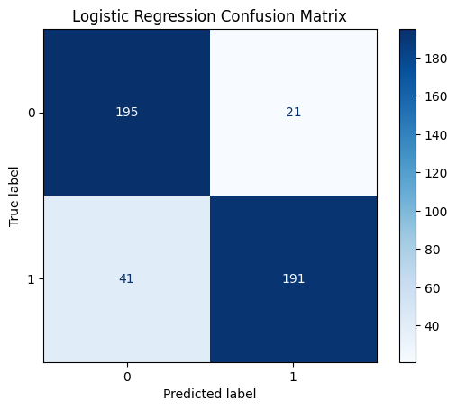

```python
print(f'Logistic Regression Accuracy is : {log_reg_model.score(X_test, y_test) * 100:.2f} %')
plot_confusion_matrix(y_test,log_reg_model.predict(X_test), "Logistic Regression")
```

### KNN

K-Nearest Neighbors (KNN) is a simple and effective algorithm for classification and regression. It finds the K nearest neighbors to a new instance in the training data and determines its class or value based on majority voting or averaging. KNN is non-parametric and doesn't assume a specific data distribution. The choice of K is important, as it affects the model's bias-variance trade-off. KNN is easy to understand but can be computationally expensive for large datasets.